ETC5543 Business Analytics Creative Activity

# From spreadsheets to decisions

A reporting and forecasting dashboard for Monash Sport

[Try the dashboard →](https://vicky-fengz.github.io/ETC5543-Monash-Sports/) [View the code](https://github.com/Vicky-FengZ/ETC5543-Monash-Sports) Download PDF

**Team**

Ayush Pandia & Ziqi Feng

**Partner**

Monash Sport

**Mentors**

Alicia Stack, Darren McLeod, Minh Huynh

**Published**

3 November 2026

# Abstract

Monash Sport records financial and operational performance in separate Excel workbooks with inconsistent layouts, making comparisons and planning difficult. This project developed an R Shiny dashboard that imports these workbooks, checks their structure and totals, and converts them into consistent tables linked to their source cells. Its pages support comparisons across sites and years and provide an Executive Dashboard for meetings. A forecasting tool uses benchmark models selected through rolling-origin evaluation and allows managers to explore payroll, price and demand scenarios. The application runs in the browser through Shinylive, keeping uploaded reports on the user’s computer. Evaluation on 38 original workbooks from 2021 to 2025 found no blocking import errors. Of 20,172 reconciliation checks, 283 identified differences between reported totals and their components. Desktop R import tests recorded speed-ups of six to thirteen times, while saved data loaded in the browser in about three seconds. Forecast accuracy and usability during routine management reporting remain to be evaluated.

# 1 Introduction

Monash Sport runs sport and recreation at Monash University. It operates health and fitness centres on the Clayton, Caulfield and Peninsula campuses, along with aquatic programs, court and facility hire, group fitness, social sport and the university’s sporting clubs. In 2024 it recorded more than 1.2 million visits, 10,438 fitness and aquatics members, 35 sporting clubs with 5,587 members and around 100,000 hours of court hire (Monash University, 2025). The university’s *Sport and Physical Activity Plan 2025–2030* also commits to “data-informed approaches” when deciding where to put effort and investment in programs and facilities, which assumes managers can see clearly how each part of the organisation is doing.

Monash Sport records financial and operational performance in three families of Excel workbooks: Monthly Site Reports, Detailed Site Reports and Venues Tracking Reports. The available reports for 2021 to 2025 comprise 38 workbooks. Management uses them to review monthly and annual changes in internal meetings and to report to university management.

According to Monash Sport staff, the current format has been in use for at least ten years. It has grown one file at a time, and how the workbooks relate to each other is not clearly documented. To compare one site’s income with last year, or with another site, someone has to open several files and line up the rows by hand. Layouts change from year to year, and summary rows sit next to the detail rows they total, so trends are hard to follow across files. The workbooks are also difficult to show in a meeting. A dashboard puts the most important figures on one screen so they can be read at a glance (Few, 2006; Sarikaya et al., 2019), and this is what Monash Sport asked for. Finally, the reports only look back: they cannot show what the coming months might look like if wages or prices change.

This project, carried out with Monash Sport for the ETC5543 Business Analytics Creative Activity, built an interactive R Shiny dashboard. Staff upload the report workbooks as they are. The dashboard checks their structure and totals, turns them into consistent tables in which every value can be traced back to its Excel cell, and shows financial and operational results for the whole organisation, each site and each facility. A forecasting page uses the same data to estimate income and expenses for the next few months under different payroll, price and demand assumptions. Everything runs in the web browser, so the confidential workbooks never leave the user’s computer. The dashboard is available at https://vicky-fengz.github.io/ETC5543-Monash-Sports/.

# 2 Objectives and significance

The project aims to give Monash Sport a dashboard it can keep using after the project ends. Staff need to be able to read it easily and trust its figures, and it has to keep working as new reports arrive each year. To meet the objectives below, the project built an R Shiny dashboard on an import pipeline that reads and validates the three report families, added a forecasting tool based on simple benchmark models, and evaluated both with automated tests on synthetic workbooks and on the 38 real workbooks for 2021 to 2025.

## 2.1 Data objectives

The figures on the dashboard need to be accurate and consistent. They should agree with Monash Sport’s own reports, and a measure such as income or visits should mean the same thing for every site and every year, even though the reports were never designed to be read together.

Users also need a reason to trust what they see. If someone questions a figure in a meeting, it should be possible to trace where it came from. If a report contains something unexpected, users should be warned when they load it, before the figure reaches a chart.

The data side also has to be reusable. Monash Sport will keep producing reports in its current format, so next year’s reports should load without a developer changing the dashboard. Other people should also be able to reproduce and check the work without seeing the confidential data.

## 2.2 Dashboard objectives

The first dashboard objective is to consolidate separate reports into a coherent view of Monash Sport’s performance. Managers should be able to assess whether income exceeds expenditure, compare actual results with budgets, and identify changes across sites, facilities and activities. Clear metric definitions and separation of organisation totals, site summaries and detailed observations are essential to prevent misleading visualisations, even when the charts appear visually convincing.

The second objective is to support both executive reporting and detailed investigation without duplicating the reporting process. Managers need a concise presentation view that highlights key results without requiring repeated navigation or scrolling. When a result raises questions, the detailed pages should allow users to examine monthly trends, site performance, programs and operational measures. Both levels should present consistent information at different levels of detail, allowing managers to move from an overall result to its underlying components.

The third objective is to enable comparisons at a meaningful level with those who are not analysts. Filters need to be clearly defined as to the reporting year and scope, chart legends, titles and labels need to be clearly differentiated between Income and Expenses; Actual and Budget; and monthly and year-to-date. Missing reporting periods should be identified as unavailable rather than represented as zero values. If it is not possible to see the labels rounded off in a graph, the user should be able to view the underlying reported data.

Finally, it needs to be user-friendly following the handover. The pages, calculations and chart functions must be modularized and the interface must be sensible even if upload of only one report family or a new reporting year is possible. The objectives are evaluated in Section 7 and limited by the limits in Section 7.8.

## 2.3 Forecasting objectives

The forecasting tool should give management a realistic picture of the coming months, based on what has happened in the past. The people using it are not forecasting specialists, so the method should be easy to explain, and the forecast should show how uncertain it is.

It should also let management test a decision before making it. Questions such as “what if casual pay rates rise?” or “what if prices go up and demand falls?” should be answerable on the page, with the assumptions behind each answer kept in view so the plan can be explained to others.

## 2.4 Significance

The dashboard brings comparisons that previously required several workbooks into a single interface. Staff will still compile the workbooks each month, but can then compare sites and years using a consistent set of figures. This supports the university plan’s commitment to data-informed decisions (Monash University, 2025). The forecasting tool extends this reporting workflow to planning under alternative cost and price assumptions.

The approach is also unusual in working with the existing workbooks as they are. It needs no database or server, keeps the confidential reports on the user’s own computer, and links every figure on the dashboard back to its source cell. The code is published with synthetic versions of the workbooks, so others can run, check and adapt the work without access to the real data.

# 3 System design

## 3.1 Users and requirements

The dashboard is built for Monash Sport’s management team. Managers work with Excel reports every month but do not use R or other programming languages, so they need an interface that requires no software installation or coding. In meetings with the project team, the mentors set two firm requirements: confidential reports must not be sent outside Monash Sport, and monthly and annual results must be brought together for presentation in meetings. The remaining requirements reflect the existing Excel workflow and the need for staff to use the dashboard independently after handover (Table 1).

Table 1: Requirements for the dashboard and how the design responds to them.

| Requirement | Source | Design response |
| --- | --- | --- |
| Confidential reports must stay within Monash Sport | Mentors | The dashboard runs in the user’s own browser, and reports are uploaded from the user’s computer |
| Monthly and annual results shown together for meetings | Mentors | Organisation-level pages and a one-page Presentation View |
| No programming or new tools for users | Users’ skills | Opened from a web link; all actions use buttons and menus |
| Reports read in their current format | Existing practice | Importers built around the existing workbook layouts |
| Keeps working in future years | Existing practice | New report years load without code changes; Excel templates |

## 3.2 Architecture

Figure 1 shows the data flow. GitHub Pages supplies the application code, which runs as R in the user’s browser through Shinylive (Schloerke et al., 2026) and webR. The Data page passes uploaded workbooks to the data layer for import, cleaning and validation. All pages, including Forecasting, use the resulting long tables through shared calculations. Cleaned data can also be saved locally and reloaded in a later session (Section 4.3).

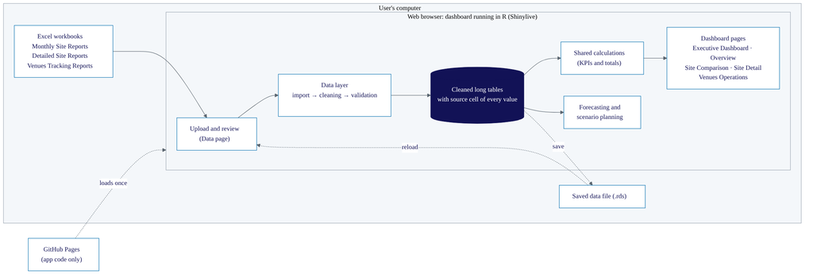

Figure 1: Architecture of the dashboard. Everything inside the grey box runs on the user’s computer; GitHub Pages provides only the application code, and no report data is sent to a server.

The code is organised the same way. Each report family has its own import, cleaning and validation scripts under `R/data/`, each page is a separate Shiny module (`R/mod_*.R`) (Wickham, 2021), and the calculations and charts used by several pages live in shared files. Pages depend only on the cleaned tables and not on each other, so one page can be changed, or a new one added, without editing the others.

The dashboard is written in R (R Core Team, 2025). The interface is built with shiny (Chang et al., 2026), bslib (Sievert et al., 2026), bsicons (Sievert, 2023) and htmltools (Cheng et al., 2025). Workbooks are read with readxl (Wickham & Bryan, 2026) and cleaned tables are exported to Excel with writexl (Ooms & Denney, 2026). All charts are drawn with base R graphics, and the forecasting models use the stats package that comes with R. The browser version is built with shinylive, and the package versions used are recorded with renv (Ushey & Wickham, 2026) so that the environment can be reproduced. This report was written in Quarto (Allaire et al., 2022) with knitr (Xie, 2025).

## 3.3 Design principles

The team chose R Shiny over business intelligence tools such as Power BI or Tableau mainly for flexibility. The workbooks have irregular layouts that change between years, and reading them correctly takes custom parsing and validation code that is easier to write and test in a programming language. R also keeps the data processing, the dashboard and the forecasting models in one code base. Staff access the app through a web link, without installing R or managing a software licence.

Browser execution meets the privacy requirement without requiring users to install R. In a conventional server-hosted Shiny deployment, uploaded reports would be processed on the server. Shinylive keeps that processing on the user’s computer, at the cost of slower execution than desktop R. Import optimisation and explicit saving of cleaned data address that trade-off (Section 7.6). File upload was also the practical choice because the project team had no access to Monash Sport’s finance or booking systems, and it leaves users in control of the source workbooks.

The pages were initially organised around the three report families, with Overview for the Monthly Site Reports, Site Comparison, and a single Detailed Analysis page. After working through the workbooks, the team split Detailed Analysis into Site Detail and Venues Operations because the Venues Tracking Reports record different measures from the other business units. The Executive Dashboard came from mentor feedback. The mentors found the existing pages detailed, but presenting them in a meeting meant switching between pages and scrolling. The Executive Dashboard and its Presentation View put the selected figures and charts on one screen.

The visual design follows the Monash brand guidelines (Monash University, 2026). Key figures and the main chart series use Monash blue. Navigation and highlights use the brighter tertiary blues, which give the dashboard a livelier look suited to a sport organisation and distinguish it from the main university website. Every chart uses orange, a brand colour for data visualisation, as its second colour, so two series being compared are easy to tell apart. The layout is designed for laptops and projected screens, where the dashboard will be used, and also adapts to narrower windows.

## 3.4 Documentation and handover

Because Monash Sport staff will use and maintain the dashboard without the project team, the project includes documentation for each audience. A step-by-step user guide, written for staff with no coding experience, covers loading the reports, each page, forecasting and the messages the dashboard can show. It is published as a web page and a PDF and is linked from the dashboard’s navigation bar. A separate maintainer guide explains how to run the dashboard in RStudio, test changes against the real reports and publish a new version, and a data dictionary documents every cleaned table and column (Table 8). Blank Excel templates with guide sheets help staff prepare reports that the importers can read (Section 4.4).

# 4 Data pipeline: from workbooks to tidy tables

## 4.1 Source reports

Monthly Site Reports record each site’s monthly Income and Expenses, with Actual results alongside the Budget planned for the year, and combine them into an organisation total. Each workbook has nine worksheets: a finance summary for the whole organisation, one sheet for each site, and a dashboard sheet with charts.

Detailed Site Reports are completed annually by Aquatics, Caulfield, Health & Fitness, Participation Program, Peninsula and Venues. They break financial results down by facility and program and add visits, memberships and enrolments. Each workbook has between five and eighteen worksheets, depending on the business unit. The Caulfield and Peninsula reports, for example, include a separate sheet for every month.

Venues, the unit responsible for courts and facility hire, also maintains a separate Venues Tracking Report. Its sixteen worksheets cover finance, casual hours and wages, attendance, bookings, facility and court hire, memberships, online sales and merchandise, alongside operational logs such as cancellation reasons and service desk calls.

Much of the early work went into reading these sheets one by one and deciding what to import. Two questions guided the choice. Does the information describe how Monash Sport is performing, and is it recorded in the same way every month and every year, so that it can be compared over time and across sites? The financial results and the main operational measures, such as visits, memberships, enrolments, facility hire and casual wages, pass both tests and are imported. Free-text sheets such as monthly highlights and help notes are left out because they cannot be summed or compared. The charts already drawn in the workbooks repeat numbers that are imported anyway, and operational logs such as cancellation reasons do not feed any performance measure. Leaving them out also keeps the dashboard to what management asked to see.

The workbooks also differ from each other in many small ways, and the differences change from year to year. Worksheets appear in a different order, are added in some years, or carry the year in their name (for example, `2025 Casual Hours`). Sheet names and labels sometimes have extra spaces, abbreviations or spelling variations, and months are stored as text in some sheets and as Excel dates or numbers in others. Summary rows and totals sit beside the detail rows they add up, and months that have not been reported yet are often filled with zeros. A person reading one workbook hardly notices these differences, but a program cannot assume that a value will always be in the same cell.

The data also have limitations that shape what the dashboard can show. The workbooks are summary reports: they record monthly totals by site, facility and program, but no individual transactions, bookings or customers, so the dashboard cannot analyse behaviour below that level or estimate how customers respond to price changes. The history is short, covering 2021 to 2025 at monthly frequency, and the Venues Tracking Reports start only in 2022. Casual salaries in the Venues Tracking Reports are the only wage data available, and it is not known whether they cover every casual employee. Some workbooks also contain missing months or totals that do not match their components, which the dashboard reports rather than corrects (Section 4.2).

The original Monash Sport workbooks are confidential and are not included in the public repository. Dashboard figures and worked examples presented in this report use synthetic workbooks that reproduce the source layouts with randomly generated values. Evaluation results concerning import success, validation checks and processing times were obtained from the original workbooks; only aggregated test results are reported, without disclosing confidential financial or operational figures.

## 4.2 Import, cleaning and validation

Each report family is processed in three steps. The import stage finds the required worksheets by name and reads their cells. Cleaning locates data blocks through labels such as the month names and the `INCOME` and `EXPENSES` headings, then reshapes them into long tables. Validation checks the resulting structure and totals against the rules for that report family.

Label searches accommodate the layout changes described in Section 4.1. A fixed reference such as “income for January is in cell B7” breaks when someone inserts a row, whereas the headings can still identify the block. Separate scripts allow changes to one family’s importer to be tested independently and help distinguish file-reading, reshaping and validation errors.

The cleaned data use a long, or tidy, format (Wickham, 2014), with one row for each value and columns describing its site or business unit, measure, Actual or Budget status, month and value (Figure 2). Retaining the workbooks’ wide layouts would have required separate processing for each report and page. The common structure supports filtering, grouping and plotting across report families, and a new month or site adds rows rather than columns.

Each row also records the file, worksheet, row and column of its source cell. These references support the mentors’ meeting workflow: a questioned figure can be traced back to the workbook. They also helped locate importer errors during development. The tables and their columns are listed in the appendix (Table 7 and Table 8).

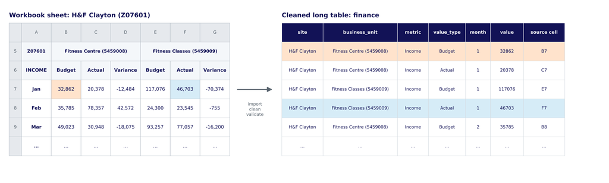

Figure 2: The same values in a Monthly Site Report worksheet (left) and in the cleaned `finance` table (right). Each value becomes one row that records its source cell; the Variance columns are not imported. Synthetic data.

Cleaning standardises labels so that a facility or membership type spelled two ways is counted as one item across years. Months that have not yet been reported are retained but marked as unreported. This preserves the gap in reporting without treating zero placeholders as actual results that would pull down trends and year-to-date averages.

When a workbook reports a year-to-date or facility total, the cleaned data retain that official figure. Independent recalculations are used for validation rather than to replace it, and totals are kept separate from their components to avoid double counting. Variance columns are not imported because they can be calculated from Budget and Actual; storing them would create a second version of the same measure that could disagree with the calculated value. Each measure also has a unit and an aggregation rule in a configuration file, so rates and averages are not added together.

Validation distinguishes errors that prevent reliable import from warnings that require review. Errors block files with incompatible structures, conflicting report identities or overlapping coverage. Warnings flag incomplete data and reconciliation differences without automatically changing the reported values.

Checks operate within and across workbooks (Table 2). Within a workbook, they examine required sections, months and totals. Across files, they identify overlapping report years and gaps that could otherwise make a trend appear continuous.

Table 2: Main validation checks, the level at which each is reported, and why.

| Check | Example | Level | Reason |
| --- | --- | --- | --- |
| Structure | A workbook without the `INCOME` and `EXPENSES` sections, or a file that is not a recognised report | Error | Importing it could put wrong or mislabelled figures on the dashboard |
| Completeness | A month missing from a sheet, or a year missing from the series of reports | Warning | Available figures can still be inspected, but coverage is incomplete |
| Reconciliation | A reported total that differs from the sum of its components | Warning | The reported figure is kept, and staff are told where to check the source workbook |
| Across files | Two reports for the same year, or a file name whose year differs from the year inside the workbook | Error | Using the file would count figures twice or assign them to the wrong year |

For example, Total Revenue in the Monthly Site Reports is checked against Actual Income plus revenue opportunity, the income given up through student, staff and other discounts. A mismatch produces a warning with the source location. The reported figure is retained for staff review because the importer cannot determine which source value should change.

## 4.3 Upload workflow

The upload workflow went through several versions. The first draft of the app read the workbooks from a fixed project folder, which does not work in the browser, where the dashboard can only read files the user chooses. The first upload design used a single box for all three report types, but each family has its own importer, and a workbook sent to the wrong importer failed in ways that were hard to trace. The page was therefore split into three boxes, one per report family, so that each error could be tied to a single file and importer.

The three boxes were reliable but left users to sort the workbooks by family. A later rewrite of the upload logic recognises each workbook from its file name, using the same naming rules as the importers, and also made parsing in the browser faster without changing any output (Section 7.6). An option to upload all reports at once was first added alongside the three boxes and, once it had proved reliable, replaced them with a single Add data card. The card accepts individual files, whole folders and saved data files, and asks for a report type only when a file name cannot be recognised.

Files are then processed one at a time, and each one gets a status (queued, parsing, ready or failed) with its warnings or error message beside it. If an updated version of a file fails to load, the previous version stays in use. The View Cleaned Data tab shows the cleaned tables with filters and search and exports them to Excel, so users can check the dashboard’s figures against their own reports.

A workbook with an unrecognised file name waits for the user to choose its report type or dismiss it. If the choice does not fit the workbook, the dashboard explains the mismatch. Non-report files, including Excel’s temporary lock files and unrelated documents, are ignored. A summary distinguishes files that were matched, skipped, left for classification or ignored.

Files already loaded with the same name and contents are skipped, avoiding repeated parsing when a folder is selected again. Cross-file checks (Table 2) and the blank-template check stop files that would double count or mislabel figures, or contain no figures. The upload controls pause during parsing because overlapping uploads fail in the browser version.

Browser performance also made it important to avoid reparsing the workbooks in every session. The first plan was for the dashboard to download the imported data automatically after each upload, so that users would not have to remember to save it. This proved hard to make reliable under Shinylive, and it would have written confidential figures to the user’s computer without the user choosing to do so or deciding where they were stored, which is a particular risk on shared computers. The final design keeps saving as an explicit step: users click Save current data to download the cleaned tables as a single `.rds` file and store it with their reports. Downloads themselves needed extra work in the browser version. Shinylive serves a download from the R session running in the page, but an ordinary download link opens a separate request that cannot reach that session, so the browser saved a broken file instead. A small JavaScript helper fetches the file from within the page and saves it from memory, which makes saving the cleaned data, exporting tables to Excel and downloading forecast plans work in the browser. An automated test checks the helper’s file names, file contents, error messages and repeated clicks.

Loading this file restores the cleaned data without reading the workbooks again. It records which reports it contains and when it was saved, and the dashboard warns users when it is more than 30 days old. A saved file can also be selected together with workbooks. It is loaded first, and changed workbooks replace matching saved copies after successful import and validation. Damaged saved files, or files from an older version whose tables have a different structure, are refused with a message, and the current session is left unchanged.

## 4.4 Extending to future years

Future-proofing was treated as an explicit design requirement, recognising that Monash Sport’s reporting processes may continue to evolve. The team wanted to give staff the flexibility to add ordinary reporting years and supported categories without having to request the original developers to edit the app every time. The importers use the file names and the headings of the relevant workbooks to guess the reporting years and verify that the guessed years match with the ones provided by the source if available. The available years in the reporting controls are not hard coded, but rather are based on data that is successfully uploaded. The reporting-context helpers also identify available sites and report families, which, if a new period is added or a partial upload, does not need to be configured manually for every page. This behaviour is important because the person who is preparing the meeting might be receiving some reports, but not others.

The import pipeline is intentionally designed to be extensible in known Excel layouts. The newly defined audience categories, new lines in the source fields, new labelled discount types and other source fields can remain in the cleaned tables, and the metric-definition file `config/metric_definitions.csv` contains central rules for the units and aggregation of recognised or newly defined measures. Unrecognised values within supported worksheet areas are retained, where possible, in additional_data, together with their source locations and warnings. Unsupported worksheets are flagged for review and require additional extraction rules before their contents can be incorporated into the cleaned tables. They are not shown on already existing KPIs or charts as totals. This separation ensures that subsequent additions don’t assume an unknown number’s business usage. Even if new business relationships or a significantly different workbook structure, explicit extraction and validation rules still need to be applied.

The R Shiny implementation also considered some future maintenance issues. The individual pages exist in individual modules and share reporting-context, calculation and plotting helpers. This will limit the range of a changed KPI, category selector or chart, but will not eliminate dependency testing of the changed KPI, category selector or chart between pages. Source-file, worksheet, row and column identifiers enable the replacement developer to find the source of unexpected values in the dashboard. Blank Excel templates, synthetic sample workbooks, the data dictionary, `tests/README.md` and the developer maintainer guide provide examples and instructions without distributing confidential Monash Sport data. The guides explain how to update importers when report templates change, verify calculations, run regression tests and deploy updated versions.

These are measures that enhance the ability of the system to adapt, but they do not ensure that the system can always be compatible. They were tested using future-year and extensibility tests in Section 7.5, and are discussed in Section 7.8 for their untested boundaries.

# 5 The dashboard

The dashboard transforms validated reporting data into views that help managers answer specific performance questions. It contains six reporting and analysis pages, alongside the Data page described in Section 4.3. Rather than reproducing the structure of individual workbooks, the pages follow different management needs, progressing from organisation-wide results to site comparisons, operational detail and forward planning. Table 3 summarises the purpose of each page.

Table 3: Dashboard pages and the management questions they support. The Data page provides workbook uploads, validation and cleaned-data review.

| Page | Main question | Reporting view |
| --- | --- | --- |
| Executive Dashboard | What should management focus on during meetings? | Overview, Site and Venues summaries, with Year Review, Comparison and Presentation View |
| Overview | How has Monash Sport’s financial performance changed over time? | Organisation-wide Income, Expenses, Net Result and Budget Variance |
| Site Comparison | How does financial performance differ across sites? | Site-level comparisons and facility financial breakdowns |
| Site Detail | How are visits, memberships and enrolments changing? | Site activities, audiences, memberships and enrolments |
| Venues Operations | Which activities and costs contribute to venue operations? | Attendance, facility hire, memberships, sales, casual hours and wages |
| Forecasting | How could payroll, pricing and demand changes affect future performance? | Baseline forecasts and scenario planning |

## 5.1 Executive Dashboard: reporting for meetings

The Executive Dashboard was created based on the feedback that the detailed pages were useful for investigation, but not convenient for presentation. The manager who is providing results in a meeting should not have to repeatedly switch pages or explain that the chart on the screen is for a different year than the headline figures. Four headline indicators, a consistent array of charts and an explanatory summary are gathered in the revised executive page, all with consistent year controls and a full-screen Presentation View.

It is broken down into three viewpoints. The total Income, Expenses, Net Result and Budget Variance are highlighted in **Overview**. There are four charts that display the monthly income and expenses, annual performance trends, budget vs actual expenses and income, and a Financial Summary and Key Insights. **Site** emphasizes the difference between the reporting units. This information is displayed on its charts, which include Income, Expenses and Net Result, Direct and Indirect visits, Active Memberships and Enrolments against targets, with financial rankings and site-level insights following. **Venues** include operational activity (attendance by activity, facility-hire revenue, Casual Wages Budget / Actual, merchandise / equipment related sales). Those charts are linked to the headline measures through a Venues Operational Summary and Key Insights. The basic visual structure remains the same, with each perspective addressing a distinct management question.

For example, a negative Net Result on the Executive Overview indicates that reported expenses exceed income for the selected period, but does not explain the underlying causes. The Site view helps managers identify which reporting units contribute to the overall result, while the Venues view highlights operational activities and costs that can be investigated further. This progression from headline results to supporting measures provides a clearer basis for discussion than presenting unrelated charts without a defined hierarchy. The Key Insights summarise observed patterns rather than establish causal relationships; for instance, an increase in attendance alongside higher wages does not demonstrate that one caused the other.

**Year Review** looks at one year selected and **Comparison** compares that year to another year. These are all presented separately to minimise unintentional comparisons between non-compatible time periods. Both modes have the same reporting context for the title, values and charts. Presentation View expands the selected Executive Dashboard summary for display on a projected screen, while more detailed analysis remains available on the other dashboard pages. Legends stay close to their titles, and hover read-outs indicate the exact number when a presenter wants to know if a number is a visual estimate or the actual value. These features have been added in response to problems of overcrowding, poor legibility of the legends and excessive scrolling required to see a full summary.

## 5.2 Organisation-wide financial overview

The Overview page provides a longer time perspective that might not be shown in a one year presentation. Users choose the years for which they wish to analyse and view the latest year in that period summarised by four indicators: Total Income, Total Expenses, Net Result and Budget Variance. Monthly charts show if a change is persistent, seasonal or limited to specific months, and annual charts are able to show overall direction for the year. Net Result is calculated as Actual Income minus Actual Expenses and indicates whether income exceeds expenditure. Budget Variance compares actual performance with budgeted values, and its interpretation depends on the measure: higher-than-budgeted income and higher-than-budgeted expenses have different implications. Keeping these measures separate prevents users from interpreting a positive numerical variance as necessarily favourable.

One of the design challenges was the relationship between an organisation total and the site values that make up the total. The finance workbooks contain both, so adding all the rows you have would double count the same thing. The page avoids combining organisation summary rows with their underlying site-level detail, preventing double counting. Shared calculation functions ensure that financial measures remain consistent across the Overview, Executive Dashboard, Site Comparison and Forecasting pages. This is essential for reliable reporting because double-counted income could produce misleading comparisons and affect the interpretation of subsequent financial analyses. The cross page consistency checks are described by Section 7.2, the same definitions are reused by the site and forecasting pages.

## 5.3 Site Comparison and Site Detail

Site Comparison is designed to address issues like which facility contributed to a site’s actual financial performance versus another facility, or which site has performed better than the other. The page displays similar financial metrics at the reporting unit level, and a detailed facility-level view for a selected facility. This “apples to apples” methodology and year selection prevents comparisons between the Income at one site and the Net Result at another. If more than one facility is located under a single site, the interface is designed to prevent the same totals from being interpreted as separate observations in the site level comparison.

Site Detail is used to answer questions about the site beyond the scope of finance. Direct and indirect visits, activities and audience groups, membership metrics, and targets and/or enrolment results can be examined. These are not interchangeable measures; a visit is an occurrence of attendance, a membership a balance at a moment in time, and enrolments participation in programs. The dashboard will thus not feed in various types of indicators under a generic count of ‘activity’. Not all business units provide each measure or measure type; the page shows the information but does not consider data not available to be zero.

The operational pages needed special attention to make for easier readability on chart. Initial efforts to include all subcategories on one graph obscured differences in the audience or differences in activity types, with labels overlapping one another. The detailed views were easier to read when the information was broken up into focused charts; the original category labels from the reports were left on the charts and only used selectors where they clarified the comparison made. Hover information was added to supported charts to allow for the checking of a point without having to use the height of a bar or the approximate position of the line.

## 5.4 Venues Operations

A separate page is necessary for venues as they have more detailed operating measures in their tracking workbooks than the other site reports. Attendance, facility and court hire, memberships, online sales, merchandise activity/equipment, casual hours/casual wages are included on the page. These measures are various parts of operations and cannot be summarized into one financial chart. The ability to group them into related views enables management to look at an attendance pattern one way, with a different view of the same pattern of hire revenue, if any.

The Venues worksheets also differ in the operational categories they report. Space Hire and related sections contain fewer activity categories than Tennis, while student and customer classifications vary between operational areas. Applying a fixed category list across all sections would create empty or misleading groups. The dashboard therefore updates its selection options according to the chosen operational area, while retaining the original category labels for attendance and transaction measures. Although this approach adds complexity to the interface, it preserves the distinctions present in the source data and supports more meaningful comparisons.

The Venues dashboard displays budgeted and actual casual wages together so that managers can assess whether expenditure is above or below budget and examine the size of the difference. The direction of the variance is interpreted in the context of expenditure rather than assumed to be favourable whenever the numerical value is positive. Monthly and year-to-date attendance and facility-hire values are also kept separate because combining them would double count activity. These decisions preserve the reporting distinctions established during data cleaning and validation in Section 4.2.

## 5.5 Shared interactions and interpretation

Common navigation, filters and visual language are used on the pages. Contrasting series are distinguished by colour and the title of the chart and the legend tell what they are. The value of the KPI is rounded for faster reading; the detailed values are available on chart hover or in the cleaned-data review. Near charts, the report year and the scope for comparison are displayed in order to avoid having to recall a choice made in another part of the app.

Reporting coverage is not complete for every measure or period. Where a reporting year or month is missing, charts preserve the gap rather than displaying an invented zero or drawing a continuous trend across unobserved periods. Measures that are not available for a particular reporting unit are also treated as unavailable rather than as zero. Together with source-cell traceability, these rules ensure that the visualisations remain faithful to the information recorded in the original workbooks.

The dashboard is thus organized as a path of explanation: begin with the result, look at the units or periods to see if there’s a problem, check the detailed measure, and then review the original report if necessary. This is a defensible basis to discuss, not an automatic recommendation for the program or facility that Monash Sport should expand or cut.

# 6 Forecasting and scenario planning

The pages in Section 5 show what has already happened, but management also has to plan ahead. One decision comes up regularly: when staff pay rates rise, how much do prices need to rise to cover the extra cost? The project’s academic mentor, Minh Huynh, suggested adding a forecasting tool. The team first planned to forecast income, expenses and budget, and discussions with Monash Sport then narrowed the focus to this pay and price question. The resulting page produces a baseline forecast of income and expenses that users can adjust for changes in payroll, prices and demand.

## 6.1 Forecast data preparation

The forecast covers Monash Sport as a whole and uses the monthly Actual Income and Expenses recorded in the Monthly Site Reports. The organisation-wide summary is used where it exists, and the site summaries only when it does not, so the same activity is never counted twice. Individual sites are not forecast. The pay and price question concerns the whole organisation, and the casual salaries used in the payroll scenarios are not split by site.

Before a model is fitted, the monthly series is checked and trimmed. A month is used only if it has both Income and Expenses. Missing months split the history, and the model trains on the latest unbroken run of complete months, since the models below assume a continuous monthly series. At least 12 such months are needed, and the page shows a notice when fewer than 24 are available.

Months at the end of the series in which both Income and Expenses are zero are a special case, because in these reports a zero often means “not yet reported”. The page lists these months and asks the user whether they are real results, and leaves them out unless the user confirms them. Forecasting stops altogether if Actual records overlap or a monthly total is negative, as either case points to a problem in the source data that should be checked before any plan is made.

## 6.2 Model selection

The tool compares a small set of simple models (Hyndman & Athanasopoulos, 2021). The naive model forecasts every future month as equal to the last observed month, and the seasonal naive model forecasts each month as equal to the same month one year earlier. When at least 30 continuous months are available, the comparison also includes additive Holt-Winters exponential smoothing (Holt, 2004; Winters, 1960), which estimates a level, a trend and a seasonal pattern from the data. With $y_t$ the value in month $t$ and $h$ the number of months ahead, the two simpler forecasts are

$$\hat{y}_{T+h} = y_T \quad \text{(naive)}, \qquad \hat{y}_{T+h} = y_{T+h-12k} \quad \text{(seasonal naive)},$$

where $k$ is the smallest whole number of years that places $T+h-12k$ within the observed data.

The team did not use more complex models such as ARIMA or regression. The history is short, often only a few years of monthly data, which is too little to estimate many parameters reliably. The dashboard also runs in the browser through Shinylive, where only some R packages are available and each extra package slows down loading, whereas the chosen models need only the `stats` package that comes with R. Management also needs to understand where a forecast comes from, and “the same as last year” or “the same as last month” is easy to explain in a meeting.

The model is chosen automatically, separately for Income and for Expenses, by rolling-origin evaluation, also called time series cross-validation (Hyndman & Athanasopoulos, 2021; Tashman, 2000). The history is cut at several past months, called origins. At each origin, every candidate model is fitted to the data up to that month and forecasts up to 12 months ahead, and its forecasts are compared with what actually happened. The tool scores the most recent 12 valid origins and selects the model with the lowest root mean squared error (RMSE). Because all models are scored on the same held-out months, the choice of test period does not favour any of them. When the history is too short for this comparison, the seasonal naive model is used as a provisional choice, because the reports show a clear yearly pattern. The selected models are recorded in the downloadable assumptions file.

## 6.3 Payroll, price and demand scenarios

The scenario tool adjusts the baseline forecast for changes that the user enters. Quick estimate forecasts the casual salaries recorded in the Venues Tracking Reports, using the same model selection process, and applies the user’s percentage pay increase to them. Manual adjustment lets the user enter a net monthly change in expenses directly, for example the cost of new hires minus the savings from a departure.

The page offers both methods because Venues casual salaries are the only wage data in the reports, and staff numbers and hours can change substantially. Quick estimate suits a general rise in casual pay rates. Manual adjustment covers planned changes that past payroll cannot reflect, such as hiring or losing staff. Only one method is active at a time.

The user can also set a price increase, the share of income that can be repriced, a change in demand, and the month from which all changes take effect.

Let $I_t$ and $E_t$ denote baseline Income and Expenses in month $t$, and let $a_t$ be an indicator equal to 1 from the effective month onwards. The pricing and demand inputs are the repriceable income share $q$, demand change $v$ and price increase $p$. Payroll uses predicted casual salaries $W_t$ and pay increase $w$ in Quick estimate, or the monthly amount $d$ in Manual adjustment. The scenario is

$$\begin{aligned}
\text{Scenario Income}_t &= I_t \,(1 + a_t v)(1 + a_t q p), \\
\text{Scenario Expenses}_t &= E_t + \begin{cases} a_t W_t w & \text{(Quick estimate)} \\ a_t d & \text{(Manual adjustment).} \end{cases}
\end{aligned}$$

Changes apply once to each affected month and do not compound. To answer the pay and price question directly, the page also calculates the minimum price increase needed for scenario income to cover scenario expenses over the whole plan:

$$p_{\min} = \max\left(0,\ \frac{\sum_t \text{Scenario Expenses}_t - \sum_t I_t (1 + a_t v)}{q \sum_{t:\,a_t = 1} I_t (1 + a_t v)}\right).$$

A price-sensitivity chart shows total income at a range of price increases next to total scenario expenses, and the point where the two lines cross is the minimum price increase. The tool does not estimate how customers respond to price changes, because the reports contain no data from which price elasticity could be estimated. The demand change is therefore the user’s own assumption, and the page labels it as one.

## 6.4 Uncertainty and interface

When enough history is available, forecasts are shown with 80% and 95% prediction intervals. For the naive and seasonal naive models, the intervals are based on the spread of past forecast errors and widen with the forecast horizon, as in the income chart in Figure 3. For Holt-Winters, they come from the fitted model. The scenario adjustments shift the intervals in the same way as the forecast, so the intervals reflect uncertainty in the baseline forecast only. They do not cover uncertainty in the payroll forecast or in the user’s assumptions about prices, demand and pay, which a note under the charts points out.

A manager needs only a few inputs to build a plan. The main controls (forecast horizon, pay increase or manual amount, and price increase) remain visible, while less common settings, such as the history period and repriceable share, sit under More options. Results combine headline figures with monthly charts and a table. Use this minimum price applies the calculated minimum to the price input, and Reset plan restores the defaults. The monthly plan and its assumptions can be downloaded as CSV files for recording and checking a decision later.

## 6.5 Worked example

Figure 3 and Figure 4 show an example plan built on the synthetic data. The baseline forecast puts total income for the year at about $8.5 million against expenses of about $11.6 million, so the plan already has a shortfall before any change is made. A casual pay increase adds about $149,000, bringing expenses to $11.7 million, and covering them requires a minimum price increase of 37.7% on all income. This is far more than the pay increase alone would require, because the price rise also has to close the existing gap. For this reason the page notes that the minimum includes any existing shortfall, and that it covers the plan as a whole, so individual months may still fall short.

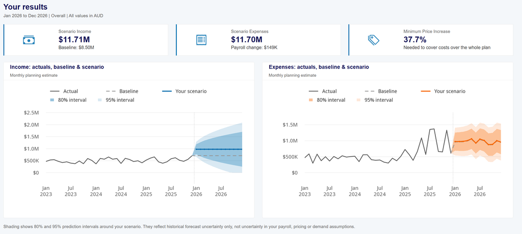

Figure 3: Results of a 12-month plan on the Forecasting page, with a casual pay increase that adds about $149,000 to expenses and prices raised by the minimum increase of 37.7%. The cards show scenario income, scenario expenses and the minimum price increase; the charts show actual values, the baseline forecast (dashed) and the scenario with its 80% and 95% prediction intervals. Figures are from synthetic data and do not reflect Monash Sport’s actual results.

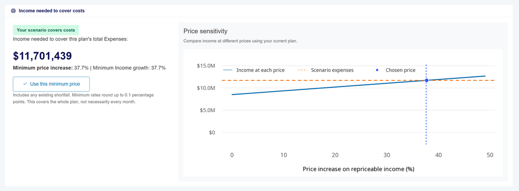

Figure 4: Income needed to cover costs and the price-sensitivity chart for the same plan as Figure 3. Total income at each price increase (solid line) crosses total scenario expenses (dashed line) at the minimum price increase of 37.7%, which is the price chosen in this plan. Figures are from synthetic data and do not reflect Monash Sport’s actual results.

# 7 Evaluation

## 7.1 Approach

The system was evaluated against the objectives in Section 2 using two kinds of evidence. The first is a set of automated tests, written as R scripts, that run the importers, the calculations and the whole app on the synthetic workbooks and on the real workbooks that Monash Sport provided for 2021 to 2025. The tests on synthetic data run through GitHub Actions every time the code changes. The tests on real data were run locally, because those files cannot leave the project team. The second kind of evidence is timing measurements of the importers and the dashboard, in desktop R and in the browser. The 27 R test scripts are summarised by area in Table 9 in the appendix, and a separate JavaScript test checks the download helper described in Section 4.3.

## 7.2 Accurate and consistent figures

All 38 real workbooks (4 Monthly Site Reports, 4 Venues Tracking Reports and 30 Detailed Site Reports) were imported without errors. Several tests then check that the cleaned figures are consistent with each other. In each workbook, the monthly totals of the individual sites must add up to the organisation summary, which tests both the reshaping and the rule that reported totals are kept as they are. A further test checks that the Income and Expenses figures are identical on the Overview, the Executive Dashboard, the Site Comparison page and in the forecasting history. Finally, 406 key annual figures from the synthetic workbooks are stored as an accepted snapshot. If a code change alters any of them, the tests fail until someone reviews and accepts the change.

## 7.3 Validation and traceability

Across the 38 real workbooks, validation raised no errors and 278 warnings. Every Monthly Site Report and Venues Tracking Report, and 28 of the 30 Detailed Site Reports, had at least one warning. The importers also ran 20,172 reconciliation checks, each comparing a total reported in a workbook with the sum of its components (Table 4). Of these, 89.6% passed and 283 (1.4%) found a difference. Most differences were in visit totals in the Detailed Site Reports (224), and the remaining 59 were spread across merchandise, facility hire, membership, Total Revenue, casual hours, court hire and finance checks. A further 9.0% could not be completed because a component or the reported total was missing, mostly in visit breakdowns that had not been filled in.

Table 4: Validation results on the real reports. A check compares a reported total with the sum of its components; counts only, so no figures from the reports are shown.

| Report family | Workbooks | Warnings | Checks | Passed | Difference found | Could not be completed |
| --- | --- | --- | --- | --- | --- | --- |
| Monthly Site Reports | 4 | 8 | 156 | 138 | 6 | 12 |
| Detailed Site Reports | 30 | 208 | 17,095 | 15,191 | 231 | 1,673 |
| Venues Tracking Reports | 4 | 62 | 2,921 | 2,747 | 46 | 128 |
| Total | 38 | 278 | 20,172 | 18,076 | 283 | 1,813 |

As intended, the dashboard reported each problem as a warning, kept the reported figures and named the file and sheet concerned. The results show that the source reports contain a small but real number of internal inconsistencies, concentrated in the detailed operational sheets, which would be hard to find by reading the workbooks one at a time.

To confirm that the checks catch problems when they occur, one test script deliberately breaks copies of the synthetic workbooks and passes them through the normal import process. Each fault in Table 5 produced the expected warning or error.

Table 5: Faults deliberately introduced into copies of the synthetic workbooks, and how validation responded.

| Report | Fault introduced | Result |
| --- | --- | --- |
| Monthly Site Report | Total Revenue changed | Warning; finance figures still imported |
|  | DISCOUNTS section removed | Warning; finance figures still imported |
|  | `INCOME` and `EXPENSES` missing from one site sheet | Warning; only that sheet skipped |
|  | Finance summary sheet removed | Warning |
|  | No sheet with finance sections | Error; nothing imported |
|  | Reports for 2022 and 2024 but not 2023 | Warning naming the missing year |
| Detailed Site Report | January Actual changed in the Finance sheet | Warning: finance check failed |
|  | Total Revenue changed | Warning |
|  | March missing from the Finance sheet | Warning naming the missing month |
|  | DISCOUNTS section removed | Error; file not used |
|  | February heading changed to January in Direct Visits | Error: duplicate month; file not used |
| Venues Tracking Report | January Indoor Actual changed | Warning: Venues finance check failed |

The same fault can lead to different results in different report families, following the distinction in Section 4.2 between errors that prevent reliable import and warnings that need review. A Monthly Site Report reads each site sheet separately, so a missing discount section only removes that sheet’s revenue opportunity figures. A Detailed Site Report has a single Finance sheet whose finance, discount and Total Revenue sections always appear together, so a missing section shows that the workbook does not follow the template, and reading it further could place values in the wrong rows. A duplicated month heading is an error for the same reason.

Separate tests run the real importers on problem files: two reports for the same year, a file name whose year differs from the year inside the workbook, a blank template, a damaged file, and a saved data file that overlaps reports already loaded. In every case the file was blocked or handled as designed, and the data already loaded stayed unchanged. Traceability is built into the data structure rather than tested separately: every row of every cleaned table carries its source file, sheet, row and column, and the View Cleaned Data tab shows these alongside each value (Figure 2).

## 7.4 Dashboard functionality and stakeholder feedback

The dashboard objectives in Section 2.2 were evaluated through cross-page numerical checks, application-level rendering tests and manual interaction testing in R using uploaded report data. Cross-page tests compare Income, Expenses, Net Result and Budget Variance across the relevant reporting views, helping identify inconsistencies introduced by changes to calculations or charts. Application-level tests also verify that pages render when only some report families are available, reflecting situations in which staff have not yet received every workbook for a reporting period.

All dashboard pages and their principal interactions were manually tested in R using uploaded data. This included filters, charts, hover readouts, and the Executive Dashboard’s Year Review, Comparison and full-screen Presentation View. These checks helped identify and resolve layout, labelling and readability issues during development and confirmed that the implemented controls behaved as intended in the R application. However, the evaluation did not measure task-completion times, accessibility compliance or consistent behaviour across different browsers and devices.

Industry mentors Alicia Stack and Darren McLeod reviewed the dashboard concept, responded positively to the proposed approach and communicated the reporting features they considered important. Their feedback informed subsequent development, particularly the presentation-oriented Executive Dashboard. In response, the team implemented consistent reporting-year controls, headline indicators, supporting charts, contextual summaries and a dedicated Presentation View. This provides qualitative evidence that the design responded to stakeholder requirements, although it does not constitute formal usability testing or acceptance during routine management operations.

The executive and detailed pages serve complementary purposes. The Executive Dashboard prioritises information suitable for management presentations, while detailed pages allow users to investigate sites, facilities and operational categories underlying the headline results. Earlier attempts to display numerous membership, activity or facility categories in individual charts caused overcrowding and overlapping labels. Dividing these measures into more focused visualisations improved readability, although it introduced additional navigation between views. Different aggregation rules were also required for monthly activity counts, financial totals, year-to-date measures and point-in-time membership balances. These distinctions increase implementation complexity but reduce the risk of misleading summaries. Independent task-based usability testing and evaluation during routine management reporting have not yet been conducted.

## 7.5 Future-proofing and reproducibility

The future-proofing objective described in Section 4.4 was evaluated using test cases beyond the original 2021–2025 reporting period. These tests introduced future-dated reports, additional metric names, new labelled fields and unrecognised worksheet values. They verified that supported additions could pass through the import, cleaning and validation pipeline, while unrecognised data were retained for inspection with their source references rather than silently incorporated into existing calculations. Additional tests examined future-year Venues worksheets, incomplete reporting coverage and compatibility between the supplied Excel templates and their respective importers.

These results demonstrate extensibility within the supported workbook structures, rather than compatibility with every possible future change. Adding a metric to a cleaned table does not automatically make it available in an existing chart. Significant changes to workbook layouts, reporting relationships or KPI definitions still require maintainer review, code modifications and regression testing. Synthetic sample workbooks, documented table structures, automated tests and the maintainer guide provide a reproducible starting point for making and verifying such changes.

## 7.6 Functional robustness and runtime performance

An app-level test starts the dashboard and renders every output on every page with seven combinations of data: no data, one report of each type on its own, one of each type together, the full set of real reports, and the full set loaded from a saved file. Every page rendered without errors, including when some report families were missing.

Profiling the importers guided an optimisation that reads each worksheet’s cells once, caches them and builds each table in a single step. Table 6 shows the effect on the real reports in desktop R. After each change, the cleaned tables were compared with those from the original version, and the faster importers produced identical results.

Table 6: Time to import each family of real reports in desktop R, before and after the import code was optimised.

| Report family (real data, desktop R) | Before | After | Speed-up |
| --- | --- | --- | --- |
| Monthly Site Reports | 30.7 s | 2.3 s | 13 times |
| Venues Tracking Reports | 79.1 s | 13.3 s | 6 times |
| Detailed Site Reports | 189.6 s | 32.5 s | 6 times |

In the browser, the published dashboard takes about 16 seconds to load, and reading the full set of real reports takes about 2 minutes 38 seconds. Loading the same data from a saved file takes about 3 seconds. In practice, a user reads the workbooks once when new reports arrive and saves the result. Before a meeting, they open the web page and load the saved file, and the dashboard is ready in about 20 seconds.

## 7.7 Forecasting

The forecasting tests check scenario calculations against values worked out by hand, including partial-year timing, demand changes, both payroll methods and the minimum price increase at which income exactly covers expenses. They also verify that candidate models use the same test periods in rolling-origin evaluation, that prediction intervals appear only with sufficient history, and that the intervals move with the scenario line.

Tests with gaps, overlapping files, short series, unconfirmed zero months and invalid manual amounts check whether the tool handles each case as described in Section 6.1 or stops with a clear message.

## 7.8 Limits of this evaluation

The tests show that the dashboard agrees with Monash Sport’s workbooks, but they cannot show whether the workbooks themselves are correct. Validation flags internal inconsistencies, such as a total that differs from its parts, while an error entered consistently in a workbook would pass every check.

The dashboard was developed in response to requirements and feedback from Monash Sport mentors. However, its usability and effectiveness have not yet been formally evaluated during routine management reporting.

Forecast accuracy has not yet been evaluated on Monash Sport’s real reports. The current tests establish computational correctness, not predictive performance.

The synthetic examples demonstrate how the dashboard behaves, but provide no evidence about Monash Sport’s actual financial or operational performance.

Systematic cross-browser, cross-device and accessibility testing was not undertaken. Browser import-time measurements indicate processing performance but do not establish how easily users can interpret projected charts, navigate between pages or complete reporting tasks independently. The effects of category density, screen size and presentation conditions should therefore be evaluated with Monash Sport staff in their normal working environment.

Future-year and extensibility tests address expected changes within recognised workbook structures and do not guarantee compatibility with every future layout or measure. Additional source fields can be retained in the cleaned data without automatically becoming inputs to existing charts or calculations. Significant changes to report templates, business definitions or reporting relationships will require corresponding updates to the importers, calculations and regression tests. Although modular code and documentation support handover, the project has not yet evaluated whether a new maintainer can independently implement and deploy such changes.

# 8 Discussion and conclusion

The project addressed a practical reporting challenge at Monash Sport: substantial financial and operational information was distributed across Excel workbooks that were difficult to compare and present consistently. The central challenge extended beyond producing visualisations. It required a defensible method for extracting information from heterogeneous workbook structures, applying consistent definitions and presenting measures that management could interpret and verify.

The completed system addresses this challenge through three interconnected components. The existing report families are converted into common tables in the import and validation pipeline, but their source locations are intact. Second, the interactive pages provide organisation level performance, site comparisons and detailed operational measures at an appropriate level to the question being asked. Thirdly, forecasting and scenario planning take the same reporting base, but apply it to questions of future income, expenses, payroll and pricing. One of the key outcomes of the iterative design process in particular is the Executive Dashboard: feedback on the difficulty of presentation resulted in a clearer distinction between a summary experience that is suitable for a meeting, and the detailed pages required for it.

The technical evaluation demonstrates that the system can process the supplied report structures consistently. All 38 original workbooks were imported without blocking errors. Across 20,172 reconciliation checks, 283 differences were identified between reported totals and their components, showing that the validation process can reveal inconsistencies rather than assume that all source figures are correct. Automated tests also assessed numerical consistency across pages, error handling, and compatibility with future reporting years. Import optimisation and the option to save cleaned data improved the practicality of browser-based delivery. These findings support the reliability of the system within the tested report structures, but do not establish that every original workbook value is accurate or that management decisions based on the dashboard will necessarily improve.

Three broader lessons emerged from development. First, data quality and traceability must be treated as part of the analytical output rather than concealed behind visually appealing charts. Validation warnings and source-cell references help users investigate unexpected results. Second, reporting measures require appropriate aggregation and comparison rules. Financial totals, monthly attendance, year-to-date activity and point-in-time membership balances represent different types of information and should not be treated interchangeably. Third, privacy and usability involve practical trade-offs. Browser-based execution keeps uploaded reports on the user’s computer but can be slower than desktop R. Explicitly saving cleaned data gives users control over the storage of confidential information while reducing repeated processing.

The principal limitations arise from the available data and the scope of evaluation. The reports contain aggregated monthly information rather than individual customer or transaction records, limiting more detailed behavioural analysis. Wage information is restricted to the casual salary measures available in the Venues Tracking Reports. Forecasting models were selected for transparency and computational simplicity, but their accuracy has not yet been evaluated against subsequent actual Monash Sport results. The pricing and demand scenarios also depend on user-defined assumptions rather than estimated customer responses. Although the dashboard was developed using requirements and feedback from Monash Sport mentors and its principal interactions were manually tested in R, formal usability testing during routine management reporting has not been conducted. Synthetic data support public demonstration and reproducibility but cannot be used to infer Monash Sport’s actual financial or operational performance.

The next priority should be evaluating the dashboard during routine Monash Sport reporting before introducing further features. Over several reporting cycles, staff could assess whether they can upload new workbooks, interpret validation warnings, investigate unexpected figures and present results without developer support. Task-based usability testing would provide evidence about whether the page hierarchy, category selectors and presentation controls support actual management workflows. Forecast accuracy should also be assessed against observations that become available after the forecasts are produced. As report templates evolve, maintainers should update the relevant importers, metric definitions and tests together. The shared calculations, source-cell traceability, regression suite and maintainer documentation provide a foundation for checking that future changes remain consistent across executive and detailed reporting views.

## 8.1 Contributions and handover

Requirements and feedback from Monash Sport mentors Alicia Stack and Darren McLeod, and academic guidance from Minh Huynh, were integrated into the project. As outlined in this report, this is a shared system, with the reporting interface relying on the import and validation pipeline and the data layer being of little use to managers unless it could be accessed through a clear reporting interface.

Ayush’s main contribution was the design and development of the R Shiny reporting and visualisation interface. This included the layout of the reporting pages, comparisons of sites and venues, operational charts and selectors, the presentation-oriented design of the Executive Dashboard, and incremental enhancements to chart readability, responsive layout and hover interactions. The key decisions were how to structure the various management queries into pages, how to maintain the meaning of management categories and timelines and how to strike a balance between executive succinctness and detailed inspection. Ayush also helped in integration, debugging and documentation of these interfaces.

Ziqi’s main contribution was the data and planning layer beneath the dashboard and its delivery in the browser. This covered the import, cleaning and validation pipeline for the three report families, the upload workflow and saved data, the Shinylive deployment and import optimisation, and the forecasting and scenario tool. Ziqi also wrote much of the automated test suite, including the tests on the real reports and deliberately broken workbooks, and prepared the synthetic workbooks, templates, data dictionary and user guide. The key decisions were how to make figures traceable without changing what Monash Sport reported, and how to keep confidential data on the user’s computer without making the tool impractical. Through the project, Ziqi learned to turn irregular spreadsheets into reliable tidy data, to treat validation and testing as part of the analysis rather than an afterthought, and to choose methods that non-specialist users can understand and trust.

Both authors participated in the review of the integrated dashboard and in the handover.

The full source code, synthetic sample workbooks, tests and documentation are available at [the project GitHub repository](https://github.com/Vicky-FengZ/ETC5543-Monash-Sports), and the [live dashboard](https://vicky-fengz.github.io/ETC5543-Monash-Sports/) demonstrates the browser version. The README file tells new users to check the user guide and the developers to check the maintainer guide, data dictionary and tests. The original confidential Monash Sport workbooks are excluded from the public repository. This handover is critical as it will allow Monash Sport to utilise and modify the system without the original team.

Overall, the project delivers a browser-accessible reporting and planning tool that transforms existing Excel workbooks into a more consistent basis for management discussions. Its principal contribution is not any individual chart or forecasting model, but the integration of traceable source data, meaningful comparisons and interactive decision-support features within a single application. The next measure of success will be its reliability and usefulness during Monash Sport’s regular reporting activities.

# Use of generative AI

## Ayush

I used ChatGPT during development and report preparation to explore R Shiny implementation approaches, troubleshoot coding and formatting issues, review chart behaviour and edge cases, and improve the clarity of documentation and written explanations. I also used it to review draft report sections and identify possible inconsistencies.

I assessed the suggested changes against the application code, available test results and project requirements, and made the final decisions about the reporting interface and its design. I reviewed the final written content to ensure that it accurately reflected the implemented functionality, evaluation evidence and limitations. Numerical results and technical claims were checked against the project materials and tests rather than accepted solely from AI-generated responses.

## Vicky

I used Claude to support parts of this project. The assistance mainly involved improving the data extraction logic, checking edge cases in the file upload process, and fixing bugs. I also used AI to refine the CSS styling of the dashboard and website, add tests for boundary conditions, and improve the grammar, clarity and flow of my report and project documentation.

I treated the AI’s suggestions as guidance and made the final design and implementation decisions myself. I reviewed and adjusted the suggested code, checked the outputs and test results, and assessed whether the changes were appropriate for the project before including them. I also reviewed the revised writing to ensure that it accurately reflected the work completed.

# References

Allaire, J. J., Teague, C., Scheidegger, C., Xie, Y., & Dervieux, C. (2022). *Quarto* [Computer software]. https://doi.org/10.5281/zenodo.5960048

Chang, W., Cheng, J., Allaire, J., Sievert, C., Schloerke, B., Aden-Buie, G., Xie, Y., Allen, J., McPherson, J., Dipert, A., & Borges, B. (2026). *Shiny: Web application framework for r*. https://shiny.posit.co/

Cheng, J., Sievert, C., Schloerke, B., Chang, W., Xie, Y., & Allen, J. (2025). *Htmltools: Tools for HTML*. https://github.com/rstudio/htmltools

Few, S. (2006). *Information dashboard design: The effective visual communication of data*. O’Reilly Media.

Holt, C. C. (2004). Forecasting seasonals and trends by exponentially weighted moving averages. *International Journal of Forecasting*, *20*(1), 5–10. https://doi.org/10.1016/j.ijforecast.2003.09.015

Hyndman, R. J., & Athanasopoulos, G. (2021). *Forecasting: Principles and practice* (3rd ed.). OTexts. https://otexts.com/fpp3/

Monash University. (2025). *Sport and physical activity plan 2025–2030*. Monash University. https://www.monash.edu/__data/assets/pdf_file/0007/4127479/Sports-and-physical-activity-plan-2025-2030.pdf

Monash University. (2026). *Brand book: colours*. Monash University. https://www.monash.edu/brandbook/brand-elements/colours

Ooms, J., & Denney, B. (2026). *Writexl: Export data frames to excel xlsx format*. https://ropensci.r-universe.dev/writexl

R Core Team. (2025). *R: A language and environment for statistical computing*. R Foundation for Statistical Computing. https://www.R-project.org/

Sarikaya, A., Correll, M., Bartram, L., Tory, M., & Fisher, D. (2019). What do we talk about when we talk about dashboards? *IEEE Transactions on Visualization and Computer Graphics*, *25*(1), 682–692. https://doi.org/10.1109/TVCG.2018.2864903

Schloerke, B., Chang, W., Stagg, G., & Aden-Buie, G. (2026). *Shinylive: Run shiny applications in the browser*. https://posit-dev.github.io/r-shinylive/

Sievert, C. (2023). *Bsicons: Easily work with bootstrap icons*. https://github.com/rstudio/bsicons

Sievert, C., Cheng, J., & Aden-Buie, G. (2026). *Bslib: Custom bootstrap ’sass’ themes for shiny and rmarkdown*. https://rstudio.github.io/bslib/

Tashman, L. J. (2000). Out-of-sample tests of forecasting accuracy: An analysis and review. *International Journal of Forecasting*, *16*(4), 437–450. https://doi.org/10.1016/S0169-2070(00)00065-0

Ushey, K., & Wickham, H. (2026). *Renv: Project environments*. https://rstudio.github.io/renv/

Wickham, H. (2014). Tidy data. *Journal of Statistical Software*, *59*(10), 1–23. https://doi.org/10.18637/jss.v059.i10

Wickham, H. (2021). *Mastering shiny*. O’Reilly Media. https://mastering-shiny.org/

Wickham, H., & Bryan, J. (2026). *Readxl: Read excel files*. https://readxl.tidyverse.org

Winters, P. R. (1960). Forecasting sales by exponentially weighted moving averages. *Management Science*, *6*(3), 324–342. https://doi.org/10.1287/mnsc.6.3.324

Xie, Y. (2025). *Knitr: A general-purpose package for dynamic report generation in r*. https://yihui.org/knitr/

## Cleaned data tables

The data layer turns each report family into a set of long tables with one row per value. Table 7 lists the columns that most tables share, and Table 8 lists the tables for each report family. The complete data dictionary, with every column and its type, is in `docs/data_dictionary.md` in the project repository.

Table 7: Columns shared by most cleaned tables.

| Column | Meaning |
| --- | --- |
| `report_year` | Reporting year of the source workbook, taken from its file name |
| `date`, `month`, `month_label` | The month the value belongs to; empty for year-to-date and total rows |
| `period_type` | `Month`, `YTD` (a year-to-date value reported in the workbook) or `Reported Total` |
| `row_type` | The kind of row in the source layout, such as a detail line, a section total or an overall total |
| `metric` | What the value measures, such as `Income`, `Paid Hours` or `New Members` |
| `value` | The number itself |
| `is_reported` | `FALSE` for months filled with zeros that have not yet been reported, which are left out of KPIs and trends |
| `source_file`, `source_sheet`, `source_row`, `source_column` | The workbook cell the value came from |

Table 8: Cleaned tables produced for each report family.

| Report family | Table | Contents | Main identifying columns | Used by |
| --- | --- | --- | --- | --- |
| Monthly Site Reports | `finance` | Monthly income and expenses | `site`, `site_code`, `business_unit`, `is_summary`, `value_type` (Actual or Budget) | Executive Dashboard, Overview, Site Comparison, Forecasting |
|  | `discounts` | Discounts given, by type | as `finance`, with `discount_type` | Executive Dashboard, Overview, Site Comparison |
|  | `total_revenue` | Annual reconciliation of actual income, discounts and reported Total Revenue | `site`, calculated and reported totals, `validation_status` | Executive Dashboard, Overview, Site Comparison |
| Detailed Site Reports | `finance`, `discounts`, `total_revenue` | As for the Monthly Site Reports, by facility or program | `report_unit`, `campus`, `fund_code` | Site Comparison, Site Detail |
|  | `visits` | Direct and indirect visits | `visit_type`, `activity`, `audience` | Site Detail |
|  | `memberships`, `enrollments` | Membership and program enrolment counts and targets | `dataset_type`, `metric`, `metric_type` | Site Detail |
| Venues Tracking Reports | `finance` | Monthly income and expenses by fund | `fund`, `row_type`, `value_type` | Venues Operations |
|  | `attendance` | Attendance by area and activity | `area`, `activity`, `category` | Venues Operations |
|  | `facility_hire`, `court_hire` | Hire revenue and transactions | `facility` or `court_type`, `category` | Venues Operations |
|  | `membership` | Membership products and movements | `membership_group`, `membership_type` | Venues Operations |
|  | `online_sales`, `merchandise` | Online and merchandise sales | `site`, `category`, `section`, `item` | Venues Operations |
|  | `casual_hours`, `casual_wages` | Budgeted and paid hours; casual salaries | `record_group`, `series`, `salary_year` | Venues Operations, Forecasting |
| All families | `*_checks`, `validation`, `files` | Results of each reconciliation check, import warnings and errors, and a summary of each uploaded file | `check_type`, `status`, `level`, source location | Data page |

## Automated tests

Table 9: Automated test scripts by area. The scripts and what each one checks are listed in `tests/README.md` in the project repository.

[output not shown]